# NGS RNA-Seq Project Progress Report: Finish Aligning and Generate Read Counts

### **QC Issues**

Signs of cyclic GC content for some runs, are present in the dataset, however fastq tile coordinates **are not available** in the GEO dataset to allow for selective tile filtering.

[Github issue showing that SRA does not store this information](https://github.com/ncbi/sra-tools/issues/130)

Particularly these issues were seen in three of the samples, with the effects occurring with varying degree. These samples were `SRR8440539`, `SRR8440524`, and `SRR8440538`.

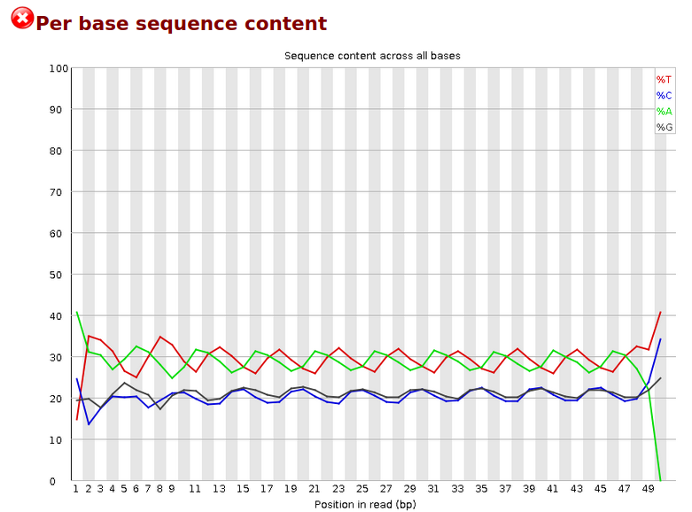

### **Calculating Percent Unmapped Reads**

```bash
#!/bin/bash

data_storage_dir=/Genomic_Data_Storage/Alzheimers_Project

trim_fastq_dir=${data_storage_dir}/trimmed_myeloid_fastqs
trim_align_dir=${data_storage_dir}/trimmed_myeloid_alignments
bam_files=$(ls ${data_storage_dir}/trimmed_myeloid_alignments/*.bam)
parallel_tmp_dir=$(mktemp -d)

calculate_unampped_reads() {
  base=$(basename $1)
  prefix=$(echo $base | egrep -o "SRR[0-9]+")

  unammped_reads_file=${trim_align_dir}/${prefix}_trimmed.Unmapped.out.mate1
  total_reads_file=${trim_fastq_dir}/${prefix}_trimmed.fq.gz
  num_lines=$(cat $unammped_reads_file | wc -l)
  num_total_lines=$(zcat $total_reads_file | wc -l)
  perc_unmapped_reads=$(echo -e "(${num_lines}/${num_total_lines})*100" | bc -l | xargs printf %.2f)
  echo -e "Percentage of unmapped reads for ${prefix}: ${perc_unmapped_reads}%" > ${parallel_tmp_dir}/${prefix}.out
}

for bam_file in $bam_files; do
  calculate_unampped_reads $bam_file &
done

cat $parallel_tmp_dir/*.out
```

```bash
Percentage of unmapped reads for SRR8440443: 5.90%
Percentage of unmapped reads for SRR8440447: 4.17%
Percentage of unmapped reads for SRR8440448: 4.04%
Percentage of unmapped reads for SRR8440449: 8.38%
Percentage of unmapped reads for SRR8440463: 33.79%
Percentage of unmapped reads for SRR8440477: 5.14%
Percentage of unmapped reads for SRR8440482: 6.54%
Percentage of unmapped reads for SRR8440484: 3.65%
Percentage of unmapped reads for SRR8440486: 8.13%
Percentage of unmapped reads for SRR8440488: 5.19%
Percentage of unmapped reads for SRR8440501: 6.98%
Percentage of unmapped reads for SRR8440511: 5.47%
Percentage of unmapped reads for SRR8440513: 6.79%
Percentage of unmapped reads for SRR8440514: 4.97%
Percentage of unmapped reads for SRR8440517: 5.76%
Percentage of unmapped reads for SRR8440518: 5.02%
Percentage of unmapped reads for SRR8440524: 11.28%
Percentage of unmapped reads for SRR8440525: 9.51%
Percentage of unmapped reads for SRR8440527: 7.05%
Percentage of unmapped reads for SRR8440529: 6.67%
Percentage of unmapped reads for SRR8440531: 10.64%
Percentage of unmapped reads for SRR8440536: 7.61%
Percentage of unmapped reads for SRR8440538: 7.43%
Percentage of unmapped reads for SRR8440539: 12.34%
Percentage of unmapped reads for SRR8440542: 8.16%
```

From the about output, we see that `SRR8440463` as an unusually high amount of unmapped reads compared to all other samples in the study. When cross-referenceing our previously generated `MultiQC` report from earlier, we can see that the GC content of this sample appears to be off compared to all other samples as well, possibly indicating contamination or other library quality issues.

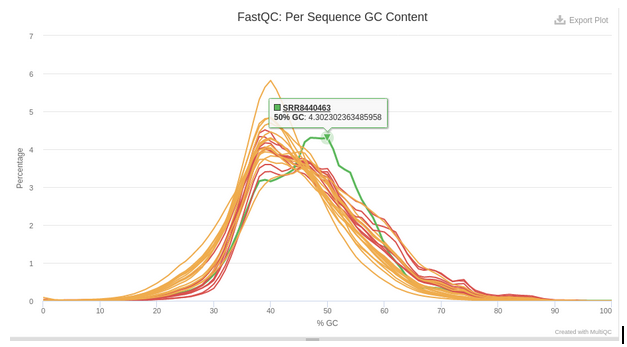

**Problematic cyclic GC samples from before**: `SRR8440524`, `SRR8440538`, and `SRR8440539` **NOT** `SRR8440463` that we see with GC-rich contamination above.

We will keep these QC issues in mind moving forward, and possibly remove the samples before analysis in `R`

### **Generating FeatureCounts**

```bash
#!/bin/bash

cell_type='myeloid'
data_storage_dir=/Genomic_Data_Storage/Alzheimers_Project

annot_file=${data_storage_dir}/human_genome_38/gencode.v36.annotation.gtf
out_dir=${data_storage_dir}/featureCounts
alignment_dir=${data_storage_dir}/trimmed_${cell_type}_alignments
out_file=${out_dir}/featCounts_genes.txt
bam_files=$(ls ${alignment_dir}/SRR???????_trimmed.Aligned.sortedByCoord.out.bam)

mkdir $out_dir

featureCounts \
  -a $annot_file \
  -o $out_file \
  -T 14 $bam_files
```

### **Forming a DESeq2 object from featureCounts data**

```r
library(knitr)
library(purrr)
library(dplyr)
library(DESeq2)
library(ggplot2)
library(magrittr)

read_counts <- read.table(
  '../featCounts/featCounts_genes.txt',
  header = TRUE, stringsAsFactors = FALSE)

orig_names <- colnames(read_counts)
colnames(read_counts) <- gsub(".*(SRR[0-9]+).*", "\\1", orig_names)
row.names(read_counts) <- make.names(read_counts$Geneid)
read_counts <- read_counts[,-c(1:6)]
read_counts <- as.matrix(read_counts)

##FILTERING OUT QC FAILED SAMPLES
keep_samples <-
  colnames(read_counts) %in%
            c('SRR8440524', 'SRR8440463',
            'SRR8440538', 'SRR8440539',
             "SRR8440484", "SRR8440488",
             "SRR8440447", "SRR8440517") %>%
  not()

read_counts <-
  read_counts[ , keep_samples]

read_counts %>%
  .[1:4, 1:5] %>%
  kable()
```

|  | SRR8440443 | SRR8440448 | SRR8440449 | SRR8440477 | SRR8440482 |
| --- | --- | --- | --- | --- | --- |
| ENSG00000223972.5 | 0 | 0 | 0 | 0 | 0 |
| ENSG00000227232.5 | 0 | 1 | 0 | 0 | 0 |
| ENSG00000278267.1 | 0 | 0 | 0 | 0 | 0 |
| ENSG00000243485.5 | 0 | 0 | 0 | 0 | 0 |

**Converting gene count Ensembl IDs to cannoncical gene names**

**gene-data from gtf files**

```r
library(stringr)
library(magrittr)
library(rtracklayer)
library(plyranges)

# TODO: Use the gtf to map gene ids to gene
# names instead of biomart

if (!exists('genes_df')) {
  genes_df <-
    read_gff("../gtf/gencode.v36.annotation.gtf.gz",
                       genome_info="hg38") %>%
    select(gene_id, gene_type, gene_name) %>%
    as.data.frame()
}


gene_info_df <-
  data.frame(gencode_id = rownames(read_counts)) %>%
  left_join(., genes_df,
            by = c('gencode_id' = 'gene_id')) %>%
  select(gencode_id, gene_name, gene_type) %>%
  filter(gene_type == 'protein_coding') %>%
  group_by(gencode_id, gene_name) %>%
  filter(row_number() == 1) %>%
  ungroup() %>%
  filter(!str_detect(gene_name, '^MT-'))

# > gene_info_df$gene_name %>% table() %>% .[. > 1]
# .
#  ACTL10 AKAP17A    ASMT   ASMTL    CD99   CRLF2  CSF2RA   DHRSX
#       2       2       2       2       2       2       2       2
#  GTPBP6   IL3RA    IL9R   MATR3   P2RY8  PDE11A  PLCXD1 POLR2J3
#       2       2       2       2       2       2       2       2
# PPP2R3B    SHOX SLC25A6  SMIM40 TMSB15B   VAMP7  WASH6P   ZBED1
#       2       2       2       2       2       2       2       2

read_counts <-
  read_counts[gene_info_df$gencode_id, ]
```

**Filtering mitochondrial reads**

Now that we have our raw read counts, lets gather information about our samples to supply to the `colData` parameter of `DESeqDataSetFromMatrix`.

```r
accession_table <-
  read.table('../accession_tables/Sra_run_table.txt',
             header = TRUE, sep = ',', stringsAsFactors = FALSE) %>%
  as.data.frame() %>%
  filter(Cell_type == 'myeloid',
         !is.na(sex)) %>%
  dplyr::select(Run, Diagnosis, sex,
         expired_age, Cell_type) %>%
  arrange(Diagnosis, sex)

accession_table %>%
  kable()
```

| Run | Diagnosis | sex | expired_age | Cell_type |
| --- | --- | --- | --- | --- |
| SRR8440448 | AD | female | 84 | myeloid |
| SRR8440514 | AD | female | 78 | myeloid |
| SRR8440538 | AD | female | 84 | myeloid |
| SRR8440477 | AD | male | 88 | myeloid |
| SRR8440501 | AD | male | 79 | myeloid |
| SRR8440486 | AD | male | 75 | myeloid |
| SRR8440542 | AD | male | 70 | myeloid |
| SRR8440463 | AD | male | 72 | myeloid |
| SRR8440511 | Control | female | 59 | myeloid |
| SRR8440518 | Control | female | 88 | myeloid |
| SRR8440443 | Control | female | >90 | myeloid |
| SRR8440529 | Control | female | 83 | myeloid |
| SRR8440527 | Control | male | 79 | myeloid |
| SRR8440449 | Control | male | 74 | myeloid |
| SRR8440482 | Control | male | >90 | myeloid |
| SRR8440513 | Control | male | >90 | myeloid |
| SRR8440524 | Control | male | 86 | myeloid |
| SRR8440525 | Control | male | 86 | myeloid |
| SRR8440531 | Control | male | 38 | myeloid |
| SRR8440536 | Control | male | 61 | myeloid |
| SRR8440539 | Control | male | >90 | myeloid |

From this accession table, we can map our accession ids to any clinical variable we like, such as `Diagnosis`, which is our main experimental group condition in this analysis. `Diagnosis` in our case tells us whether or not the diseased patient showed signs of Alzheimer’s disease or not (control).

```r
conditions <-
  colnames(read_counts) %>%
  map(~accession_table[
            accession_table['Run'] == .x, ]) %>%
  bind_rows()


sample_info <-
  DataFrame(conditions,
            row.names = conditions$Run)


DESeq.ds <-
  DESeqDataSetFromMatrix(
    countData = as.matrix(read_counts),
    colData = sample_info,
    rowData = gene_info_df,
    design = ~ Diagnosis + sex)


DESeq.ds %>%
  colData() %>%
  head() %>%
  kable()
```

|  | Run | Diagnosis | sex | expired_age | Cell_type |
| --- | --- | --- | --- | --- | --- |
| SRR8440443 | SRR8440443 | Control | female | >90 | myeloid |
| SRR8440448 | SRR8440448 | AD | female | 84 | myeloid |
| SRR8440449 | SRR8440449 | Control | male | 74 | myeloid |
| SRR8440477 | SRR8440477 | AD | male | 88 | myeloid |
| SRR8440482 | SRR8440482 | Control | male | >90 | myeloid |
| SRR8440486 | SRR8440486 | AD | male | 75 | myeloid |

```r
DESeq.ds %>%
  counts() %>%
  head() %>%
  .[,1:5] %>%
  kable()
```

|  | SRR8440443 | SRR8440448 | SRR8440449 | SRR8440477 | SRR8440482 |
| --- | --- | --- | --- | --- | --- |
| ENSG00000186092.6 | 0 | 0 | 0 | 0 | 0 |
| ENSG00000284733.1 | 0 | 0 | 0 | 0 | 0 |
| ENSG00000284662.1 | 0 | 0 | 0 | 0 | 0 |
| ENSG00000187634.12 | 0 | 1 | 0 | 1 | 9 |
| ENSG00000188976.11 | 123 | 256 | 128 | 134 | 138 |
| ENSG00000187961.14 | 65 | 48 | 6 | 29 | 56 |

### **Read Mapping Quality Assessment**

**Number of reads sequenced per sample**

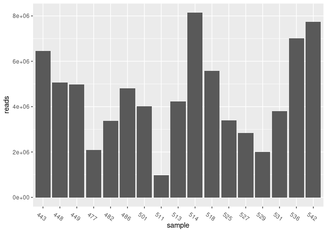

```r
library(stringr)

colSums(counts(DESeq.ds)) %>%
  data.frame(sample = str_extract(names(.), '[0-9]{3}$'), reads = .) %>%
  ggplot() +
  geom_col(aes(x = sample, y = reads)) +
  theme(axis.text.x = element_text(angle=-35))
```

Moving forward, we will filter our `DESeqDataSet` as to only include genes that have a read mapped for at least one sample.

```r
dim(DESeq.ds)
```

```
[1] 19949    17
```

```r
keep_genes <- rowSums(counts(DESeq.ds)) > 0
DESeq.ds <- DESeq.ds[keep_genes, ]
dim(DESeq.ds)
```

```
[1] 18968    17
```

**Normalizing read counts for Sequencing Depth**

**Question**: Why does `estimateSizeFactors` remove some genes?

```r
print(nrow(DESeq.ds))
```

```
[1] 18968
```

```r
DESeq.ds %>%
  rownames() %>%
  duplicated() %>%
  any()
```

```
[1] FALSE
```

```r
DESeq.ds <- estimateSizeFactors(DESeq.ds)

print(nrow(DESeq.ds))
```

```
[1] 18968
```

```r
DESeq.ds %>%
  rownames() %>%
  duplicated() %>%
  any()
```

```
[1] FALSE
```

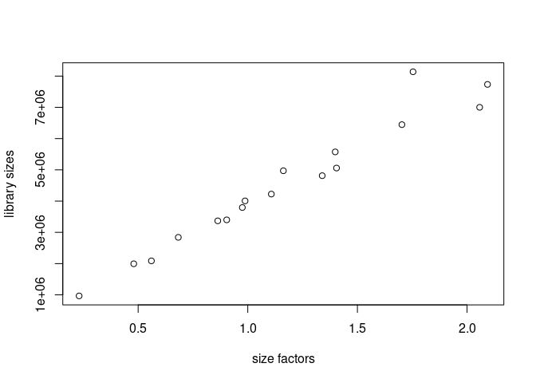

```r
plot(sizeFactors(DESeq.ds), colSums(counts(DESeq.ds)),
     ylab = 'library sizes', xlab = 'size factors')
```

Assumptions:

- Most genes are not changing across conditions
- Size factors should be around 1

```r
raw_read_counts <- read.table(
  '../featCounts/featCounts_genes.txt',
  header = TRUE, stringsAsFactors = FALSE)

orig_names <- colnames(raw_read_counts)
colnames(raw_read_counts) <- gsub(".*(SRR[0-9]+).*", "\\1", orig_names)
row.names(raw_read_counts) <- make.names(raw_read_counts$Geneid)
raw_read_counts <- raw_read_counts[,-c(1:6)]


ensembl_ids <-
  raw_read_counts %>%
  rownames() %>%
  gsub('\\.[0-9]+', '', .)

gene_name_df <-
  data.frame(ensemble_id = ensembl_ids) %>%
  left_join(., ensembl_df,
          by = c('ensemble_id' = 'ensembl_gene_id')) %>%
  mutate(hgnc_symbol =
           if_else(hgnc_symbol == "" | is.na(hgnc_symbol),
                   ensemble_id, hgnc_symbol)) %>%
  group_by(ensemble_id) %>%
  filter(row_number() == 1) %>%
  ungroup()

raw_read_counts <-
  as.matrix(raw_read_counts)

rownames(raw_read_counts) <-
        gene_name_df$hgnc_symbol

# Error in `.rowNamesDF<-`(x, value = value) :
#   duplicate 'row.names' are not allowed
# In addition: Warning message:
# non-unique values when setting 'row.names': ‘ACTL10’, ‘CCDC39’, ‘DUXAP8’, ‘GOLGA8M’, ‘HERC3’, ‘ITFG2-AS1’, ‘LINC01238’, ‘LINC02203’, ‘PINX1’, ‘POLR2J3’, ‘POLR2J4’, ‘RMRP’, ‘SCARNA4’, ‘SLFN12L’, ‘SNORA16A’, ‘SNORA17B’, ‘SNORA50A’, ‘SNORD38B’, ‘SNORD3D’, ‘TBCE’

samples <-
  DESeq.ds %>%
  counts() %>%
  colnames()

for (sample in samples) {
  print(sample)

  raw_read_counts[, sample] %>%
    .[. > 1000] %>%
    round(-5) %>%
    table() %>%
    kable() %>%
    print()
}
```

[output not shown]

**Is is the same few genes in every sample that have these high counts?**

**IT WAS MITOCHONDRIAL READS**, maybe it would be best to filter out `read_counts` matrix columns to remove mitochondrial reads before making our DESeq2 dataset.

```r
for (sample in samples) {
  print(sample)

  raw_read_counts[, sample] %>%
  as.data.frame(., row.names = rownames(raw_read_counts)) %>%
  filter(`.` > 30e3) %>%
  kable() %>%
  print()
}
```

[output not shown]

We see that our size factors are varying a bit more than around 1, though at this time we will continue with `rlog` normaliztion.

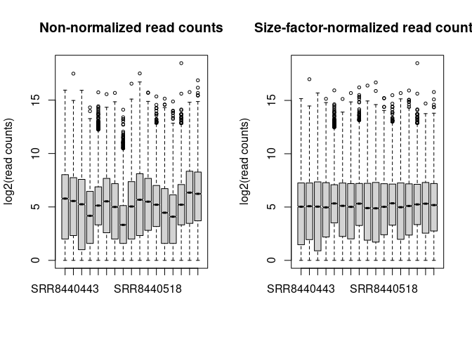

```r
par(mfrow = c(1,2))
boxplot(log2(counts(DESeq.ds)+1), notch=TRUE,main = "Non-normalized read counts",ylab="log2(read counts)", cex = .6)

## bp of size-factor normalized values
boxplot(log2(counts(DESeq.ds, normalize= TRUE)+1), notch=TRUE,main = "Size-factor-normalized read counts",ylab="log2(read counts)", cex = .6)
```

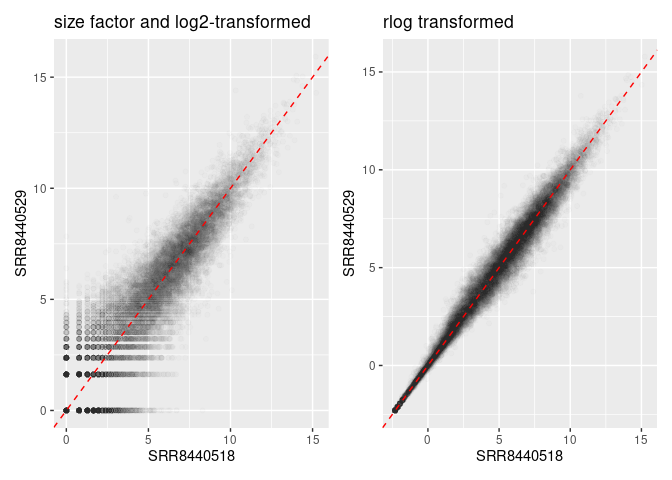

```r
library(patchwork)

if (!exists('DESeq.rlog')) {
  DESeq.rlog <- rlog(DESeq.ds, blind = TRUE)
}


log.norm.counts <-
  DESeq.ds %>%
  counts(normalized=TRUE) %>%
  {.+1} %>%
  log2()


p1 <-
  data.frame('SRR8440518' = log.norm.counts[,'SRR8440518'],
           'SRR8440529' = log.norm.counts[,'SRR8440529']) %>%
  ggplot() +
  geom_point(aes(x = SRR8440518, y = SRR8440529),
             alpha = 0.01) +
  geom_abline(slope = 1, intercept = 0,
              lty = 2, col = 'red') +
  ggtitle("size factor and log2-transformed") +
  xlab('SRR8440518') + ylab('SRR8440529')

## the rlog-transformed counts are stored in the accessor "assay"
p2 <-
  data.frame('SRR8440518' = assay(DESeq.rlog)[,'SRR8440518'],
           'SRR8440529' = assay(DESeq.rlog)[,'SRR8440529']) %>%
  ggplot() +
  geom_point(aes(x = SRR8440518, y = SRR8440529),
             alpha = 0.01) +
  geom_abline(slope = 1, intercept = 0,
              lty = 2, col = 'red') +
  ggtitle("rlog transformed") +
  xlab('SRR8440518') + ylab('SRR8440529')


p1 + p2
```

**Mean vs Stdev before `rlog`**

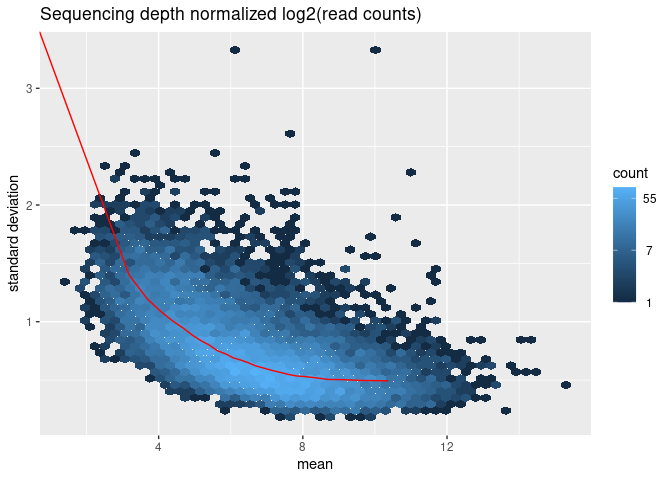

```r
log.norm.counts <-
  DESeq.ds %>%
  counts(normalized=TRUE) %>%
  log2()

par(mfrow=c(1,1))

msd_plot <-
  vsn::meanSdPlot(log.norm.counts,
                  ranks=FALSE,
                  plot=FALSE)
msd_plot$gg +
  ggtitle("Sequencing depth normalized log2(read counts)") +
  ylab("standard deviation")
```

**Mean vs Stdev after `rlog`**

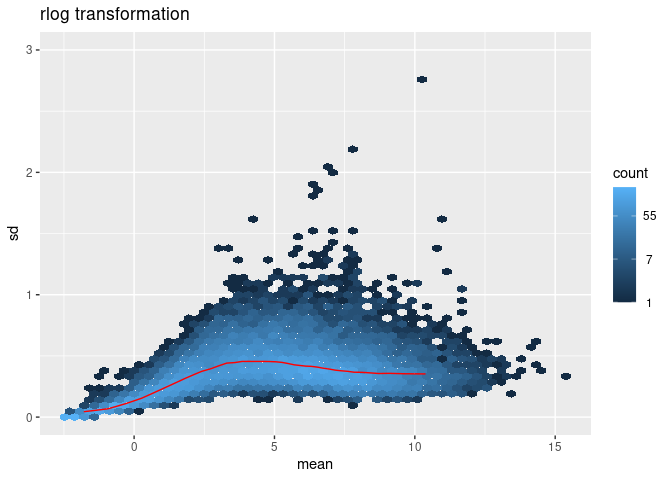

```r
rlog.norm.counts <-
  DESeq.rlog %>%
  assay()

msd_plot <-
  vsn::meanSdPlot(rlog.norm.counts,
                  ranks=FALSE,
                  plot = FALSE)

msd_plot$gg +
  ggtitle("rlog transformation") +
  coord_cartesian(ylim = c(0,3))
```

### **Male vs Female Correlation Heatmap**

First in order to check that there isn’t large differences between our male and female patient cohorts, we will generate a correlation heatmap using Pearson correlation.

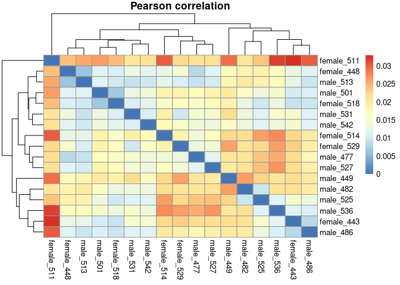

```r
library(stringr)
corr_coeff <- cor(rlog.norm.counts, method = "pearson")

new_names <- rownames(corr_coeff) %>%
  map(~accession_table[
          accession_table['Run'] == .x,
                             'sex']) %>%
  unlist()

new_names <-
  paste0(new_names, '_',
         str_extract(rownames(corr_coeff), '[0-9]{3}$'))

rownames(corr_coeff) <- new_names
colnames(corr_coeff) <- new_names

as.dist(1-corr_coeff, upper = TRUE) %>%
  as.matrix %>%
  pheatmap::pheatmap(., main = "Pearson correlation")
```

We don’t see males and females clustering too closely together here, showing support that sex should not be a confounding factor moving forward.

### **AD vs Control Correlation Heatmap**

We can now generate the same Pearson correlation heatmap from above, though this time seperating by our true varible of interest: AD vs Control.

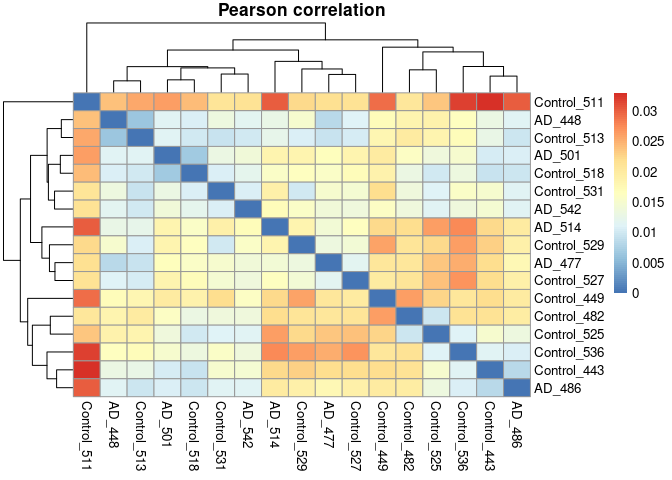

```r
corr_coeff <- cor(rlog.norm.counts, method = "pearson")

new_names <- rownames(corr_coeff) %>%
  map(~accession_table[
          accession_table['Run'] == .x,
                             'Diagnosis']) %>%
  unlist()

new_names <-
  paste0(new_names, '_',
         str_extract(rownames(corr_coeff), '[0-9]{3}$'))

rownames(corr_coeff) <- new_names
colnames(corr_coeff) <- new_names

as.dist(1-corr_coeff, upper = TRUE) %>%
  as.matrix %>%
  pheatmap::pheatmap(., main = "Pearson correlation")
```

We can also evaluate the similarity of samples with simple hierarchical clustering:

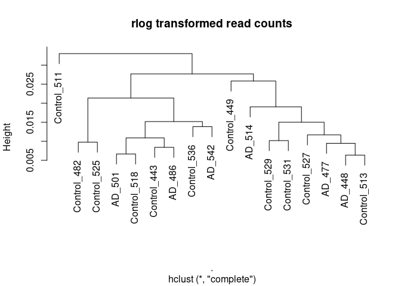

```r
rlog_corr_coeff <-
  rlog.norm.counts %>%
  cor(method = "pearson") %>%
  set_rownames(new_names) %>%
  set_colnames(new_names)

as.dist(1-rlog_corr_coeff) %>%
  hclust() %>%
  plot(.,
       main = "rlog transformed read counts")
```

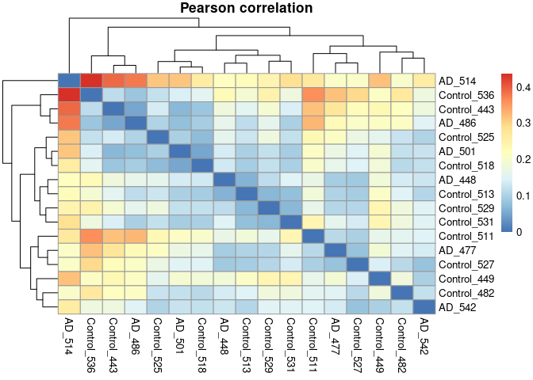

```r
## Determine 1000 most variable genes
genes <-
  assay(DESeq.ds) %>%
  apply(1, var) %>%
  sort(decreasing = TRUE) %>%
  names(.) %>%
  head(1000)

study_counts <-
  rlog.norm.counts[rownames(rlog.norm.counts) %in% genes, ]



new_names <- colnames(study_counts) %>%
  map(~accession_table[
          accession_table['Run'] == .x,
                             'Diagnosis']) %>%
  unlist()

new_names <-
  paste0(new_names, '_',
         str_extract(rownames(corr_coeff), '[0-9]{3}$'))


corr_coeff <-
  study_counts %>%
  cor(method = "pearson") %>%
  set_rownames(new_names) %>%
  set_colnames(new_names)


as.dist(1-corr_coeff, upper = TRUE) %>%
  as.matrix() %>%
  pheatmap::pheatmap(., main = "Pearson correlation")
```

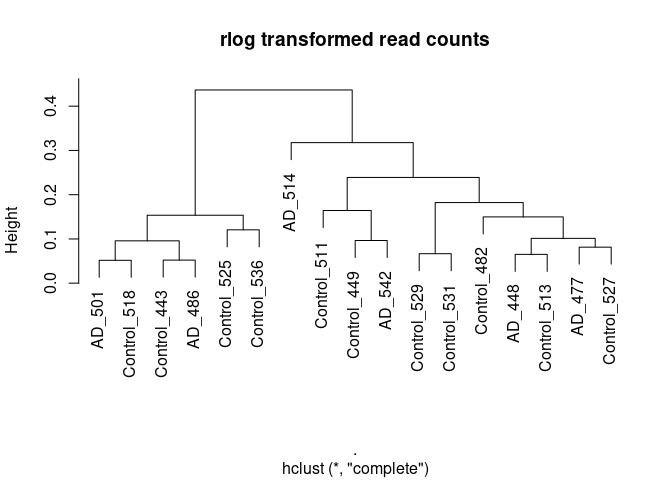

```r
rlog_corr_coeff <-
  study_counts %>%
  cor(method = "pearson") %>%
  set_rownames(new_names) %>%
  set_colnames(new_names)

as.dist(1-rlog_corr_coeff) %>%
  hclust() %>%
  plot(.,
       main = "rlog transformed read counts")
```

### **PCA**

Lastly, in order to determine the magnitude in the differences between our samples, we make use of Principle Components Analysis

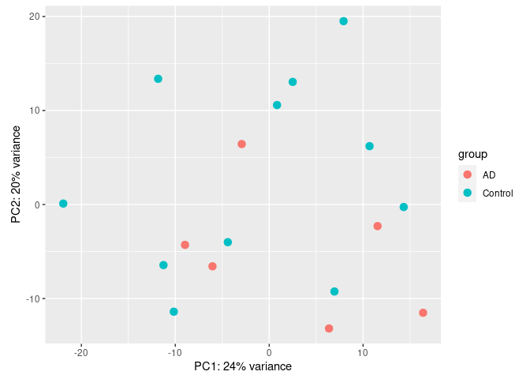

```r
plotPCA(DESeq.rlog, intgroup = 'Diagnosis')
```

**Gene-specific**

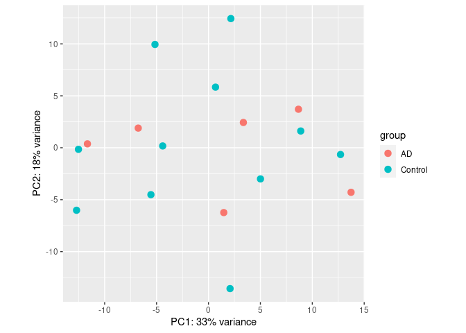

```r
DESeq.rlog.subset <- subset(DESeq.rlog, rownames(DESeq.rlog) %in% genes)

plotPCA(DESeq.rlog.subset, intgroup = 'Diagnosis')
```